# Bajram_Ajdini_me1701_code

## Time Series Analysis

Δημιουργούμε την συνάρτηση test_stationarity ώστε να κάνουμε των ελέγχω στασιμότητας καθώς και τις μεθόδους κινούμενου μέσου και κινούμενης τυπικής απόκλισης.

```python
def test_stationarity(timeseries):

    #Determing rolling statistics
    rolmean = timeseries.rolling(12).mean()
    rolstd=timeseries.rolling(12).std()


    #Plot rolling statistics:
    orig = plt.plot(timeseries, color='blue',label='Original')
    mean = plt.plot(rolmean, color='red', label='Rolling Mean')
    std = plt.plot(rolstd, color='black', label = 'Rolling Std')
    plt.legend(loc='best')
    plt.title('Rolling Mean & Standard Deviation')
    plt.show(block=False)

    #Perform Dickey-Fuller test:
    print ('Results of Dickey-Fuller Test:')
    dftest = adfuller(timeseries, autolag='AIC')
    dfoutput = pd.Series(dftest[0:4], index=['Test Statistic','p-value','#Lags Used','Number of Observations Used'])
    for key,value in dftest[4].items():
        dfoutput['Critical Value (%s)'%key] = value
    print (dfoutput)
```

```python
def AutoR(train,test):
    # train autoregression
    model = AR(train)
    model_fit = model.fit()
    window = model_fit.k_ar
    coef = model_fit.params
    # walk forward over time steps in test
    history = train[len(train)-window:]
    history = [history[i] for i in range(len(history))]
    predictions = list()
    for t in range(len(test)):
        length = len(history)
        lag = [history[i] for i in range(length-window,length)]
        yhat = coef[0]
        for d in range(window):
            yhat += coef[d+1] * lag[window-d-1]
        obs = test[t]
        predictions.append(yhat)
        history.append(obs)

    error = mean_squared_error(test, predictions)
    # plot
    plt.plot(test.values)
    plt.plot(predictions, color='blue')
    plt.show()
    print('Test MSE: %.3f' % error)
```

Για την πρώτη περιοχή έχουμε την μεταβλητή df_Entos_fi όπου περιέχει τα δεδομένα των πλοίων που είναι εντος την περιοχής . Έπειτα περούμε τα μοναδικά mmsi και t (όπου t είναι στην μορφή datetype) και με εκτελούμε την μέθοδο MapReduce για να υπολογίσει το πλήθος των πλοίων ανά ημέρα .

```python
start_time = time.time()
df_Entos_fi=df_Entos_fi.withColumn('t', f.to_date(df_Entos_fi.t.cast(dataType=t.TimestampType())))
count_time=df_Entos_fi.select("sourcemmsi","t").distinct()
g=count_time.select('t').rdd.map(lambda x: (x,1)).reduceByKey(lambda a,b: a+b)
g=g.toDF(["t",'count'])
g=g.sort('t')
gpandas=g.toPandas()
print('Ο χρόνος εκτέλεσης των εντολων είναι : ' + repr(time.time() - start_time))
```

```
Ο χρόνος εκτέλεσης των εντολων είναι : 46.57736110687256
```

Κάνουμε μερικές μετατροπές στα δεδομένα μας ώστε να είναι σε θέση για την ανάλυση χρονοσειρων . Τέλος κάνουμε ένα τεστ στασιμότητας ώστε να μπορέσουμε να εκτελέσουμε σωστά με βάση την θεωρία χρονολογικών σειρών το μοντέλο AR .

[output not shown]

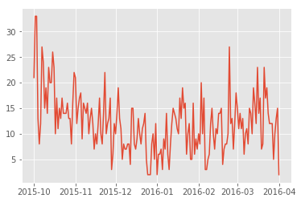

```python
start_time = time.time()
datelist = np.arange('2015-10-01', '2016-04-02', dtype='datetime64')
df1=gpandas['count']
datelist=pd.DataFrame(datelist)
df1= pd.concat([datelist, df1], axis=1)
df1.columns=['Day','Count']
df1['Day']=pd.to_datetime(df1['Day'])
df1.set_index('Day', inplace=True)
df1.index
ts1 = df1['Count']
plt.plot(df1)
print('Ο χρόνος εκτέλεσης των εντολων είναι : ' + repr(time.time() - start_time))
```

Παρακάτω καλούμε την συνάρτηση test_stationarity για τα δεδομένα της πρώτης περιοχής

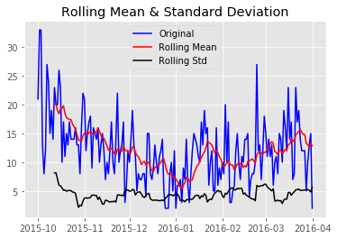

```
Results of Dickey-Fuller Test:
Test Statistic                  -2.897765
p-value                          0.045609
#Lags Used                       7.000000
Number of Observations Used    176.000000
Critical Value (5%)             -2.878106
Critical Value (1%)             -3.468062
Critical Value (10%)            -2.575602
dtype: float64
```

```python
test_stationarity(ts1)
```

Χωρίζουμε τα δεδομένα μας σε train και test sets με train να είναι τα δεδομένα εκπαίδευσης όπου περιέχουν τους 5 πρώτους μήνες και test να είναι τα δεδομένα για την επικύρωση του μοντέλου μας και να περιέχουν τον τελευταία μήνα .

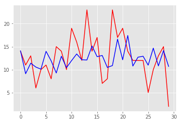

```
Test MSE: 22.323
```

```python
#8
start_time = time.time()
X = ts1
train, test = X[1:len(X)-30], X[len(X)-30:]
AutoR(train,test)
print('Ο χρόνος εκτέλεσης των εντολων είναι : ' + repr(time.time() - start_time))
```

Ακριβός με την ίδια μεθοδολογία πράττουμε και για την δεύτερη περιοχή

```python
start_time = time.time()
df_Entos_fi_0=df_Entos_fi_0.withColumn('t', f.to_date(df_Entos_fi_0.t.cast(dataType=t.TimestampType())))
count_time_0=df_Entos_fi_0.select("sourcemmsi","t").distinct()
e=count_time_0.select('t').rdd.map(lambda x: (x,1)).reduceByKey(lambda a,b: a+b)
e=e.toDF(["t",'count'])
e=e.sort('t')
epandas=e.toPandas()
print('Ο χρόνος εκτέλεσης των εντολων είναι : ' + repr(time.time() - start_time))
```

```
Ο χρόνος εκτέλεσης των εντολων είναι : 34.89466214179993
```

[output not shown]

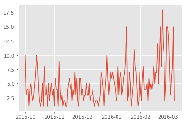

```python
start_time = time.time()
datelist = np.arange('2015-10-01', '2016-04-02', dtype='datetime64')
df0=epandas['count']
datelist=pd.DataFrame(datelist)
df0= pd.concat([datelist, df0], axis=1)
df0.columns=['Day','Count']
df0['Day']=pd.to_datetime(df0['Day'])
df0.set_index('Day', inplace=True)
df0.index
ts0 = df0['Count']
plt.plot(df0)
print('Ο χρόνος εκτέλεσης των εντολων είναι : ' + repr(time.time() - start_time))
```

Παρακάτω καλούμε την συνάρτηση test_stationarity για τα δεδομένα της δεύτερης περιοχής καθως και διαγράφουμε τα κενά στοιχειά που έχουν πρόκυψη στην μεταβλητή ts0

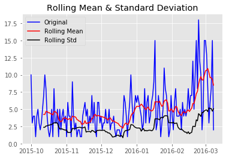

```
Results of Dickey-Fuller Test:
Test Statistic                  -2.111879
p-value                          0.239765
#Lags Used                       6.000000
Number of Observations Used    153.000000
Critical Value (5%)             -2.880623
Critical Value (1%)             -3.473830
Critical Value (10%)            -2.576945
dtype: float64
```

```python
#2
ts0.dropna(inplace=True)
test_stationarity(ts0)
```

Κάνουμε μετασχηματισμό τις τιμές που περιέχονται στην μεταβλητή ts0 σε λογαριθμική κλίματα καθώς και παρατηρούμε πως είναι διαγραμματικά ο κινητός μέσος όρος του.

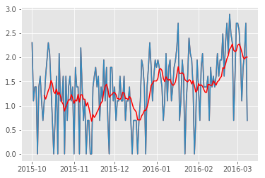

```python
#3
ts_log = np.log(ts0)
plt.plot(ts_log)

moving_avg = rolmean = ts_log.rolling(10).mean()
plt.plot(ts_log)
plt.plot(moving_avg, color='red')
```

Ξανά κάνουμε μετασχηματισμό των λογαριθμικών τιμών αφού δεν επιτύχαμε την στασιμότητα με αυτόν τον τρόπο , περνώντας της πρώτες διαφορές της μεταβλητής αυτής (ts_log).

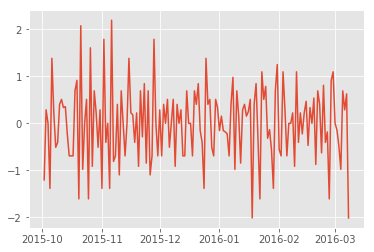

```python
#4
ts_log_diff = ts_log - ts_log.shift()
plt.plot(ts_log_diff)
```

Παρακάτω κάνουμε τον έλεγχο στασιμότητας στην καινούρια μεταβλητή.

```python
ts_log_diff.dropna(inplace=True)
dftest = adfuller(ts_log_diff, autolag='AIC')
dfoutput = pd.Series(dftest[0:4], index=['Test Statistic','p-value','#Lags Used','Number of Observations Used'])
for key,value in dftest[4].items():
    dfoutput['Critical Value (%s)'%key] = value
print dfoutput
```

```
Test Statistic                -9.058872e+00
p-value                        4.621061e-15
#Lags Used                     5.000000e+00
Number of Observations Used    1.530000e+02
Critical Value (5%)           -2.880623e+00
Critical Value (1%)           -3.473830e+00
Critical Value (10%)          -2.576945e+00
dtype: float64
```

Εκτελούμε την μέθοδο AR η όποια είναι για την πρόβλεψης των δεδομένων μας.

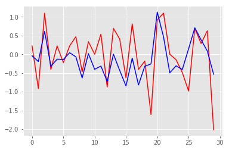

```
Test MSE: 0.363
```

```python
start_time = time.time()
X = ts_log_diff
train, test = X[1:len(X)-30], X[len(X)-30:]
AutoR(train,test)
print('Ο χρόνος εκτέλεσης της εντολής είναι : ' + repr(time.time() - start_time))
```

## K-Means

Εκχωρούμε στην μεταβλητή dataset τα ais δεδομένα τα όποια έχουν την στήλη navigationalstatus=7 και την ταχύτητα τους κάτω από 2 κομβους.

```python
dataset = df.filter((df['speedoverground']<2) & (df['navigationalstatus']==7))
```

```python
vecAssembler = VectorAssembler(inputCols=["lon","lat"], outputCol="features")
new_df = vecAssembler.transform(dataset)
```

Εκτελούμε την συνάρτηση plot1 η όποια μας κάνει απεικόνιση των δεδομένων αυτών με μονή διαφορά πλέων του δίνουμε της επιτρεπόμενες περιοχές για αλίευση.

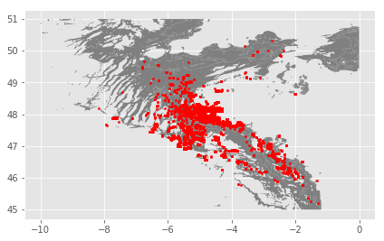

```python
dataset=dataset.toPandas()
plot1(dataset,fa,'')
```

Παρακάτω υπολογίζουμε το σφάλμα που θα έχουμε σε κάθε περίπτωση για των αριθμό των clusters που θα φτιάξουμε.

```python
start_time = time.time()
cost = np.zeros(20)
for k in range(2,20):
    kmeans = KMeans().setK(k).setSeed(1).setFeaturesCol("features")
    model = kmeans.fit(new_df.sample(False,0.1, seed=42))
    cost[k] = model.computeCost(new_df)
print('Ο χρόνος εκτέλεσης των εντολων είναι : ' + repr(time.time() - start_time))
```

```
Ο χρόνος εκτέλεσης των εντολων είναι : 937.966246843338
```

```
Text(0,0.5,'cost')
```

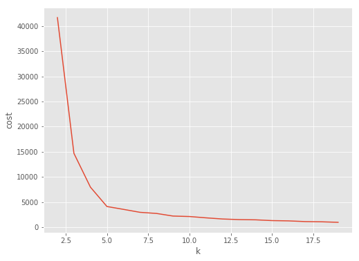

```python
fig, ax = plt.subplots(1,1, figsize =(8,6))
ax.plot(range(2,20),cost[2:20])
ax.set_xlabel('k')
ax.set_ylabel('cost')
```

Παρακάτω εκτελούμε τoν αλγόριθμο k-means της βιβλιοθήκης Mllib.

```python
start_time = time.time()
start = datetime.datetime.today()
kmeans = KMeans(k=3,seed = 100)  # 12 clusters here
model = kmeans.fit(new_df.select('features'))
end = datetime.datetime.today()
print('Ο χρόνος εκτέλεσης των εντολων είναι : ' + repr(time.time() - start_time))
```

```
Ο χρόνος εκτέλεσης των εντολων είναι : 38.359411001205444
```

Στον παρακάτω πινάκα βλέπουμε ενδεικτικά μερικά από τα δεδομένα που είχαμε προηγούμενος με μια επιπλέων στήλη η όποια περιέχει το cluster το όποιο ανήκει η κάθε γραμμή.

```python
transformed = model.transform(new_df)
transformed.show()
```

```
+----------+------------------+---------------+------------------+---------+----------+--------------------+----------+
|sourcemmsi|navigationalstatus|speedoverground|               lon|      lat|         t|            features|prediction|
+----------+------------------+---------------+------------------+---------+----------+--------------------+----------+
| 228190600|               7.0|            0.0|         -4.326842| 48.09865|1443650498|[-4.326842,48.09865]|         1|
| 228190600|               7.0|            0.0|        -4.3268385|48.098644|1443650617|[-4.3268385,48.09...|         1|
| 228190600|               7.0|            0.0|         -4.326845| 48.09864|1443650698|[-4.326845,48.09864]|         1|
| 228190600|               7.0|            0.0|        -4.3268385| 48.09865|1443650837|[-4.3268385,48.09...|         1|
| 228190600|               7.0|            0.0|        -4.3268485| 48.09865|1443650877|[-4.3268485,48.09...|         1|
| 228190600|               7.0|            0.0|        -4.3268332|48.098648|1443650916|[-4.3268332,48.09...|         1|
| 228190600|               7.0|            0.0|-4.326836599999999| 48.09865|1443650937|[-4.3268365999999...|         1|
| 228190600|               7.0|            0.0|        -4.3268332|48.098648|1443650998|[-4.3268332,48.09...|         1|
| 228190600|               7.0|            0.0|          -4.32683|48.098648|1443651057|[-4.32683,48.098648]|         1|
| 228190600|               7.0|            0.0|         -4.326832| 48.09865|1443651096|[-4.326832,48.09865]|         1|
| 228190600|               7.0|            0.0|         -4.326842| 48.09864|1443651177|[-4.326842,48.09864]|         1|
| 228190600|               7.0|            0.0|         -4.326845| 48.09864|1443651196|[-4.326845,48.09864]|         1|
| 228190600|               7.0|            0.0|        -4.3268433|48.098633|1443651238|[-4.3268433,48.09...|         1|
| 228190600|               7.0|            0.0|         -4.326832| 48.09865|1443651298|[-4.326832,48.09865]|         1|
| 228190600|               7.0|            0.0|         -4.326823|48.098656|1443651388|[-4.326823,48.098...|         1|
| 228190600|               7.0|            0.0|         -4.326822| 48.09865|1443651398|[-4.326822,48.09865]|         1|
| 228190600|               7.0|            0.0|        -4.3268285| 48.09864|1443651447|[-4.3268285,48.09...|         1|
| 228190600|               7.0|            0.0|        -4.3268332|48.098637|1443651477|[-4.3268332,48.09...|         1|
| 228190600|               7.0|            0.0|        -4.3268385|48.098633|1443651596|[-4.3268385,48.09...|         1|
| 228190600|               7.0|            0.0|          -4.32685|48.098633|1443651716|[-4.32685,48.098633]|         1|
+----------+------------------+---------------+------------------+---------+----------+--------------------+----------+
only showing top 20 rows
```

```python
pddf_pred = transformed.select("lon","lat","prediction").toPandas()
```

Δημιουργούμε την συνάρτηση Plot2 για τον λόγο ότι θα έχουμε ένα διάγραμμα το όποιο θα μας δείχνει με διαφορετικά χρώματα τα δεδομένα του κάθε cluster ξεχωριστά.

```python
def plot2(a,b):
    fig, ax = plt.subplots()
    #plt.ylim((47.7, 48.5))
    #plt.xlim((-5.5,-3.7))
    plt.title(b)
    a.plot(ax=ax, facecolor='gray');
    plt.scatter(pddf_pred['lon'], pddf_pred['lat'],c=pddf_pred['prediction'], s=10, cmap='viridis');
    plt.tight_layout();
```

Παρακάτω βλέπουμε των διαχωρισμό που έγινε σε 3 cluster

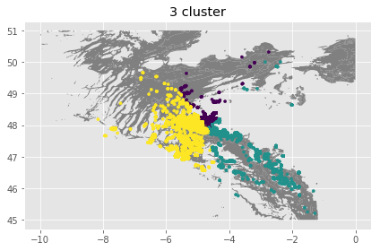

```python
plot2(fa,'3 cluster')
```

```python
wcsse = model.computeCost(new_df)
print("Within 3 Cluster Sum of Squared Errors = " + str(wcsse))
```

```
Within 3 Cluster Sum of Squared Errors = 45359.5653539
```

[figure not shown]

```python
plot2(fa,'5 cluster')
```

```python
wcsse = model.computeCost(new_df)
print("Within 5 Cluster Sum of Squared Errors = " + str(wcsse))
```

[output not shown]

Σταματάμε το Spark

```python
sc.stop()
```